# 4. Custom Fitting: MuSyC Synergy

#### 8.3.1.4 A-431 (Vemurafenib x Cobimetinib)

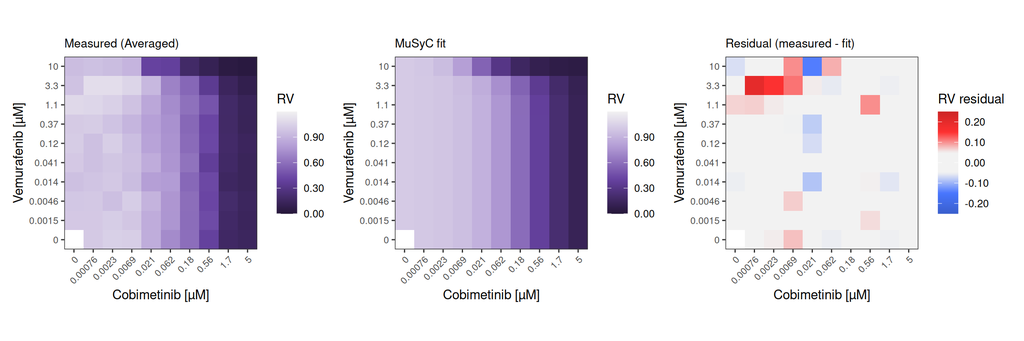

#### 8.3.1.5 A2058 (Belvarafenib x Cobimetinib)

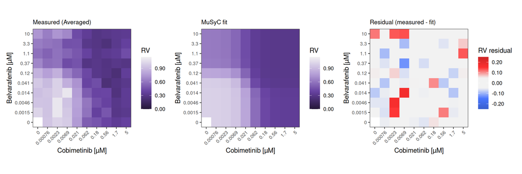

#### 8.3.1.6 A2058 (Vemurafenib x Cobimetinib)

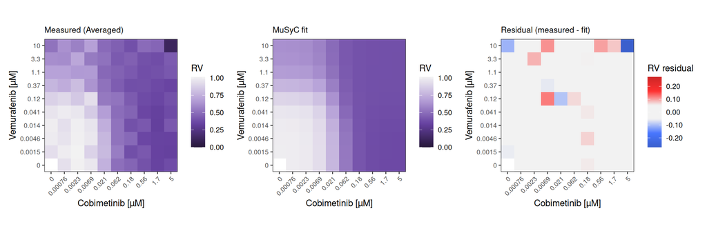

#### 8.3.1.7 COLO 800 (Belvarafenib x Cobimetinib)

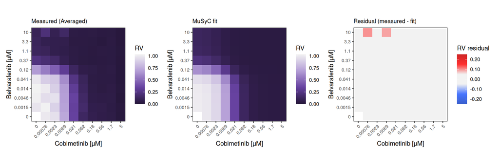

#### 8.3.1.8 COLO 800 (Vemurafenib x Cobimetinib)

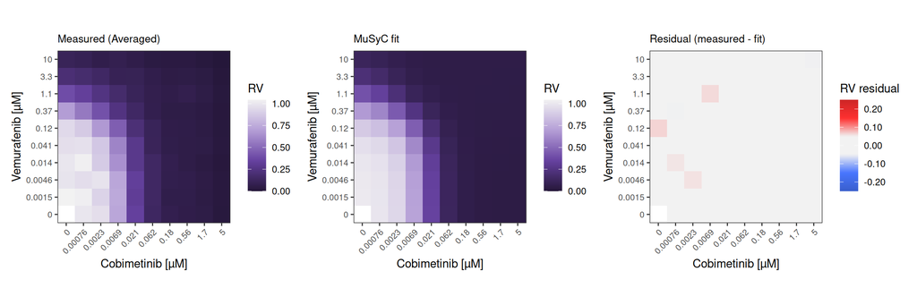

#### 8.3.1.9 COLO 829 (Belvarafenib x Cobimetinib)

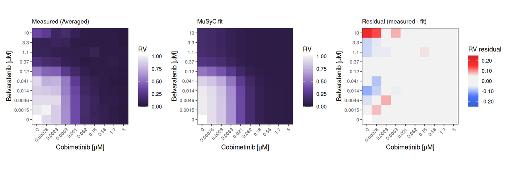

#### 8.3.1.10 COLO 829 (Vemurafenib x Cobimetinib)

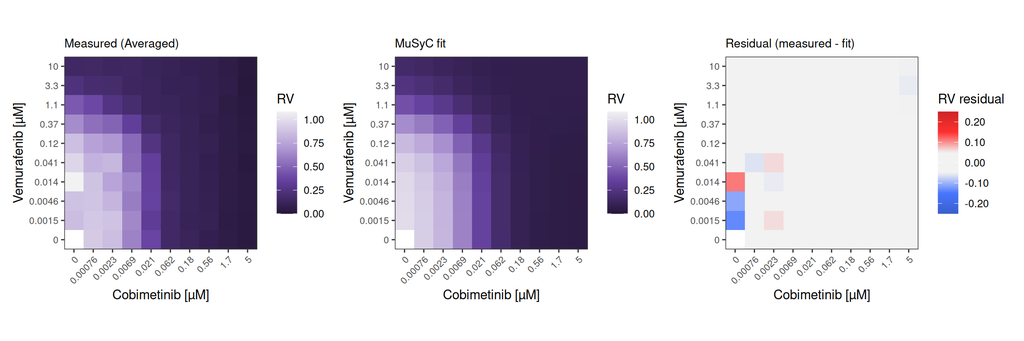

#### 8.3.1.11 HSC-1 (Belvarafenib x Cobimetinib)

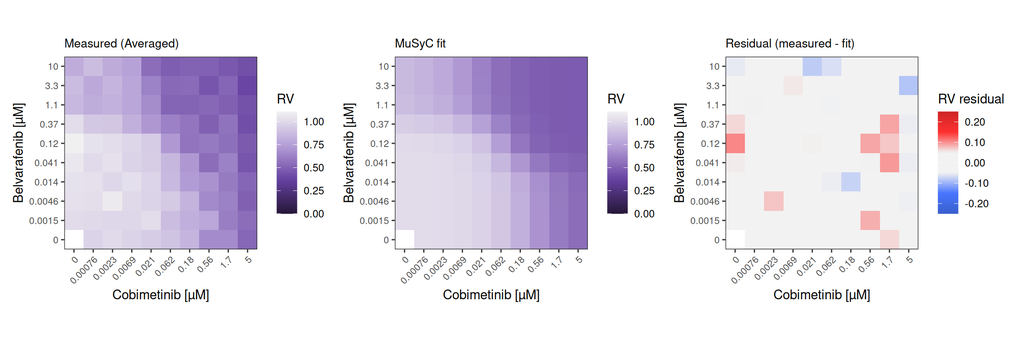

#### 8.3.1.12 HSC-1 (Vemurafenib x Cobimetinib)

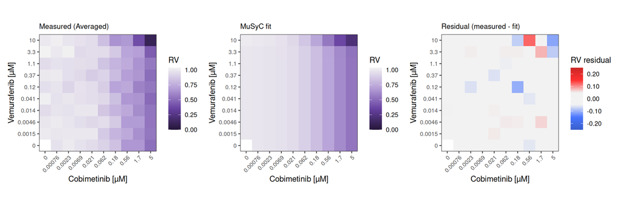

#### 8.3.1.13 HT-144 (Belvarafenib x Cobimetinib)

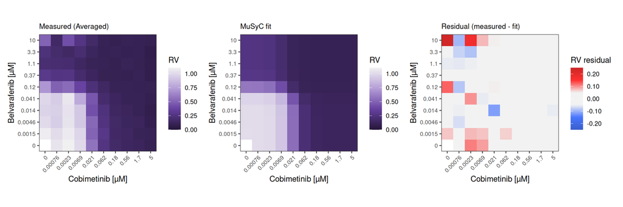

#### 8.3.1.14 HT-144 (Vemurafenib x Cobimetinib)

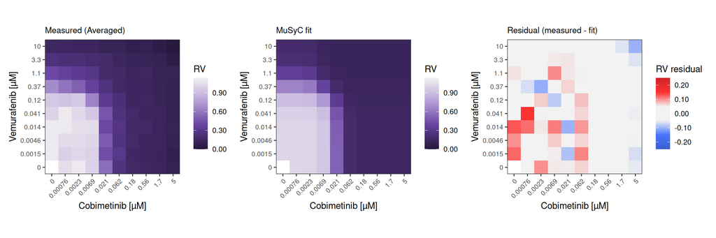

#### 8.3.1.15 MEL-JUSO (Belvarafenib x Cobimetinib)

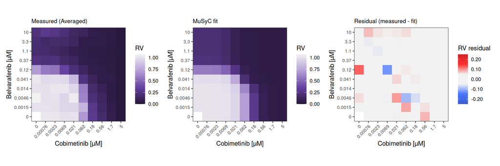

#### 8.3.1.16 MEL-JUSO (Vemurafenib x Cobimetinib)

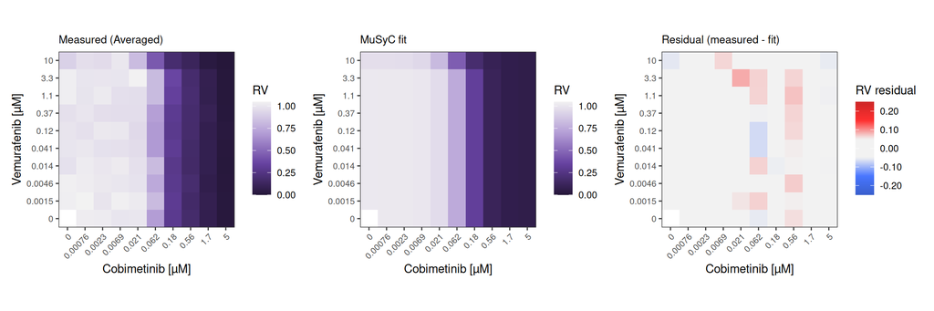

#### 8.3.1.17 SK-MEL-28 (Belvarafenib x Cobimetinib)

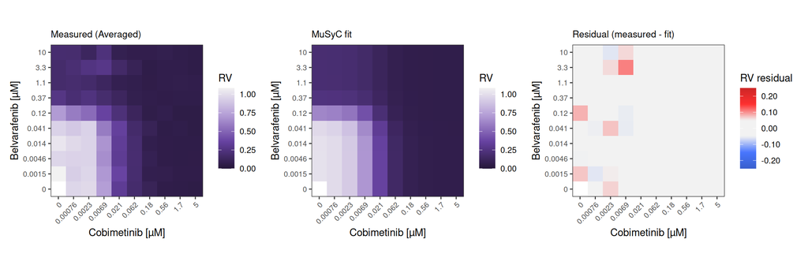

#### 8.3.1.18 SK-MEL-28 (Vemurafenib x Cobimetinib)

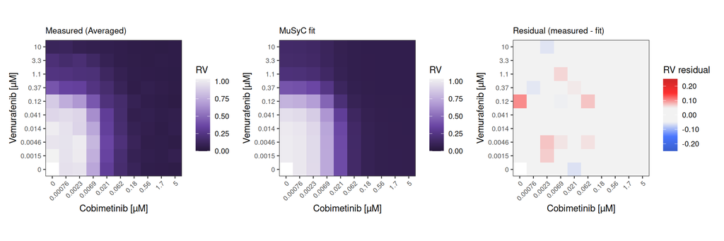

#### 8.3.1.19 WM-266-4 (Belvarafenib x Cobimetinib)

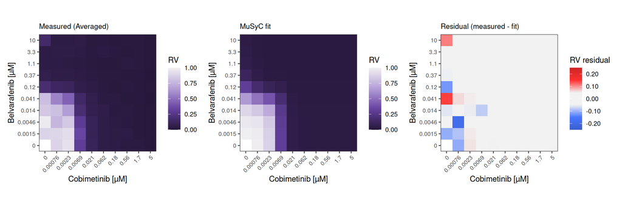

#### 8.3.1.20 WM-266-4 (Vemurafenib x Cobimetinib)

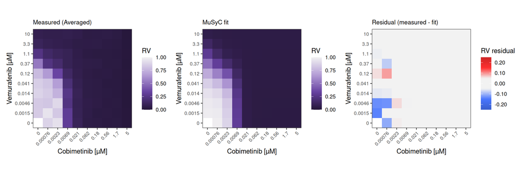

### 8.3.2 GR Value

#### 8.3.2.1 A-375 (Belvarafenib x Cobimetinib)

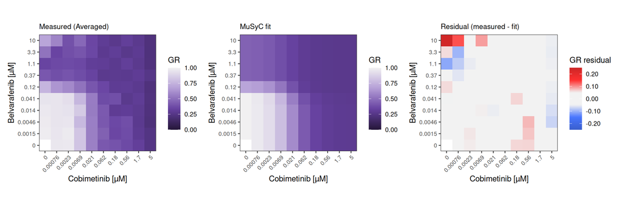

#### 8.3.2.2 A-375 (Vemurafenib x Cobimetinib)

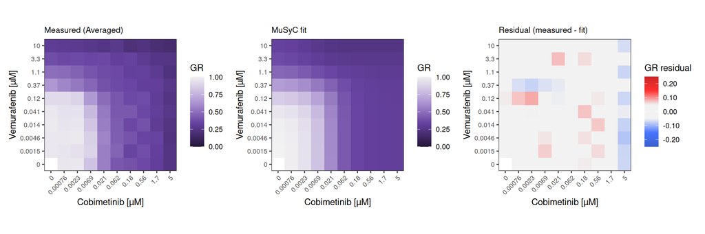

#### 8.3.2.3 A-431 (Belvarafenib x Cobimetinib)

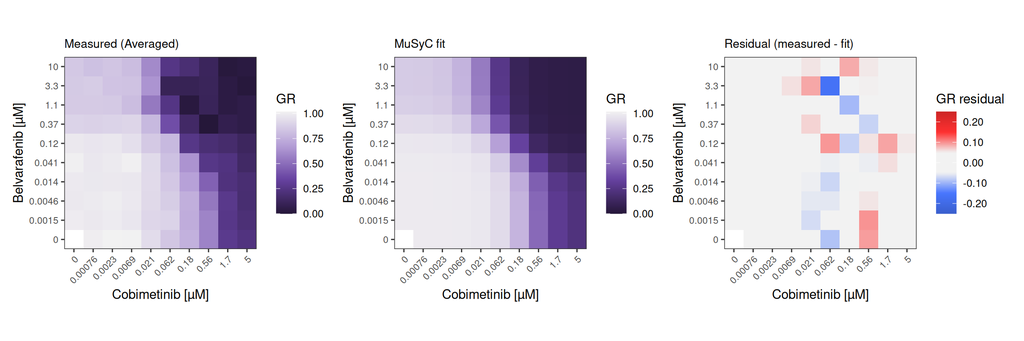

#### 8.3.2.4 A-431 (Vemurafenib x Cobimetinib)

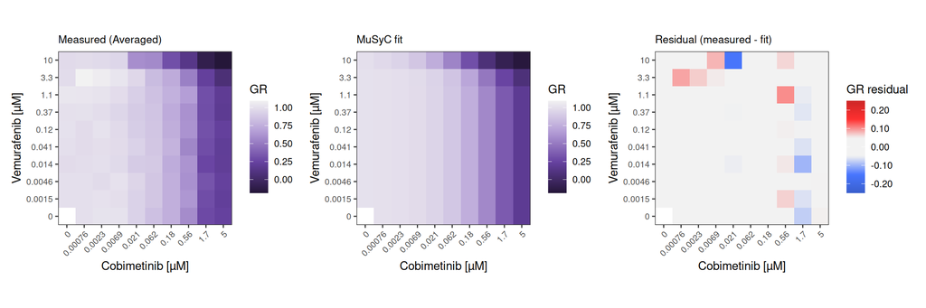

#### 8.3.2.5 A2058 (Belvarafenib x Cobimetinib)

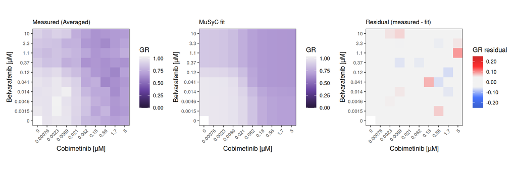

#### 8.3.2.6 A2058 (Vemurafenib x Cobimetinib)

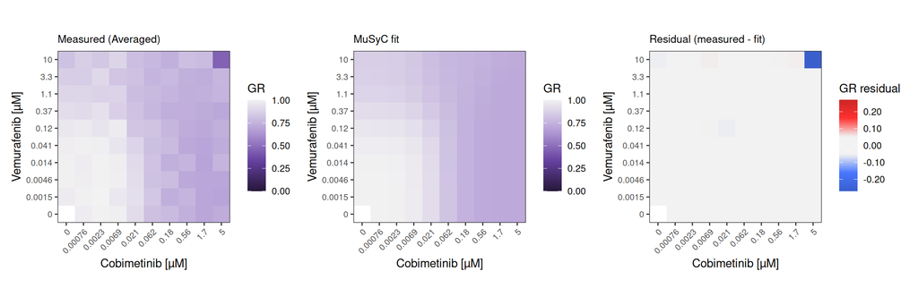

#### 8.3.2.7 COLO 800 (Belvarafenib x Cobimetinib)

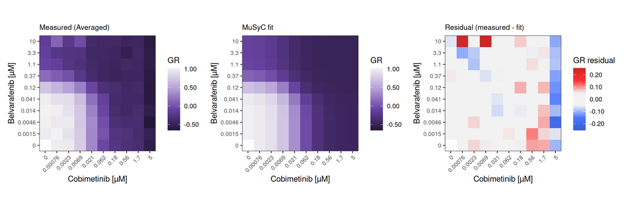

#### 8.3.2.8 COLO 800 (Vemurafenib x Cobimetinib)

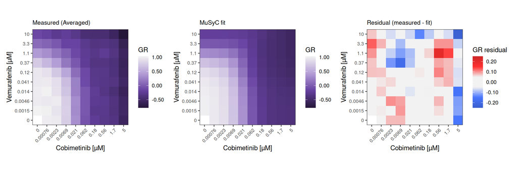

#### 8.3.2.9 COLO 829 (Belvarafenib x Cobimetinib)

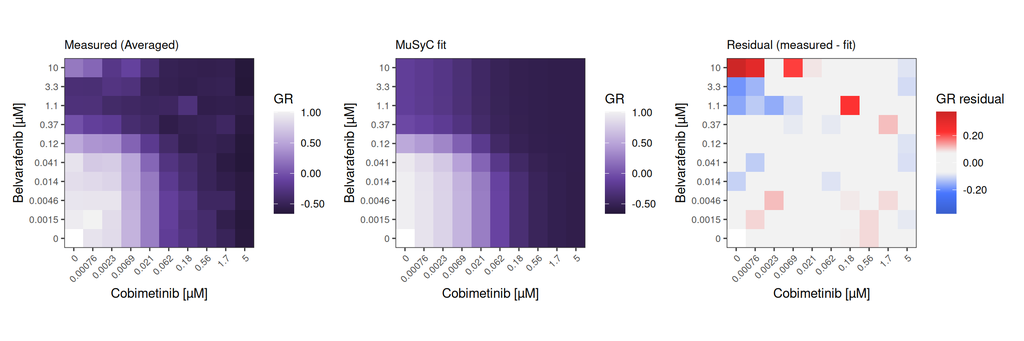

#### 8.3.2.10 COLO 829 (Vemurafenib x Cobimetinib)

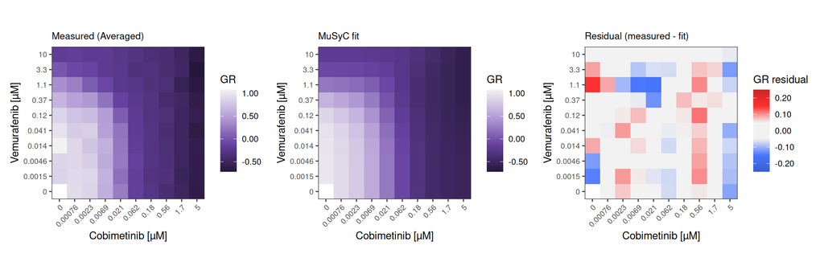

#### 8.3.2.11 HSC-1 (Belvarafenib x Cobimetinib)

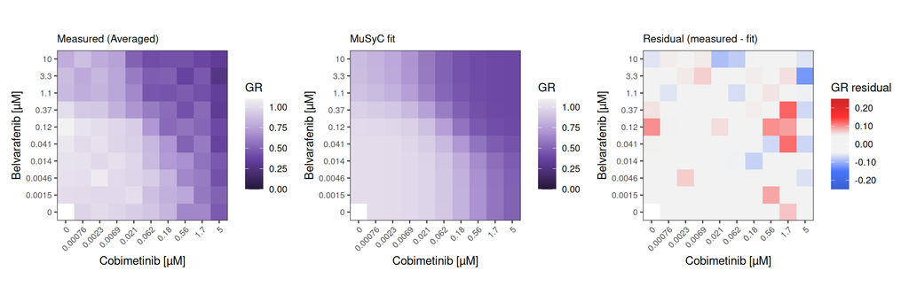

#### 8.3.2.12 HSC-1 (Vemurafenib x Cobimetinib)

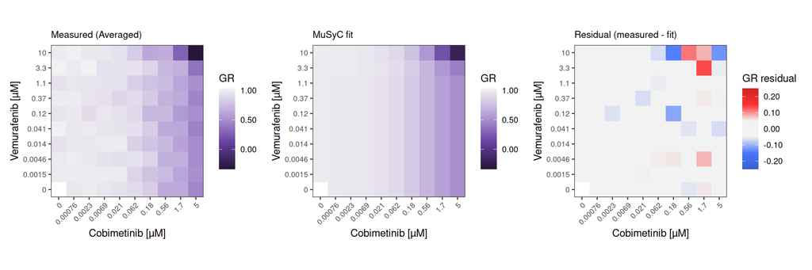

#### 8.3.2.13 HT-144 (Belvarafenib x Cobimetinib)

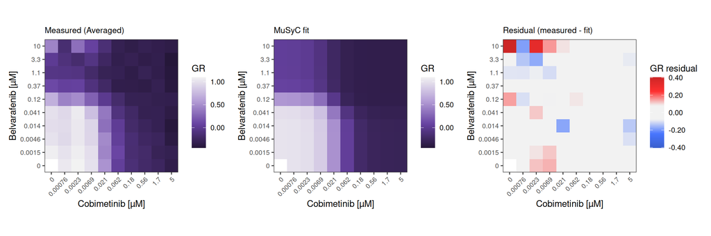

#### 8.3.2.14 HT-144 (Vemurafenib x Cobimetinib)

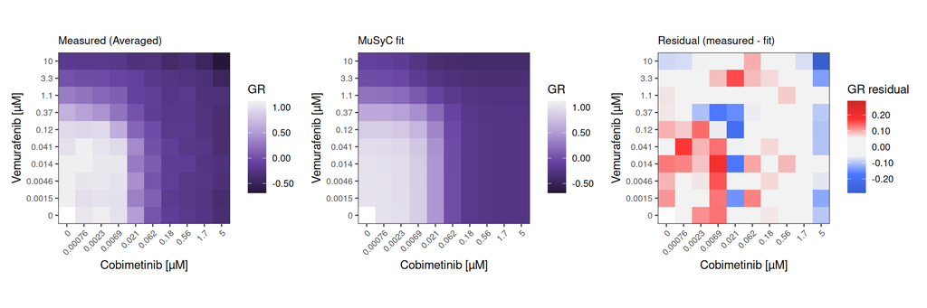

#### 8.3.2.15 MEL-JUSO (Belvarafenib x Cobimetinib)

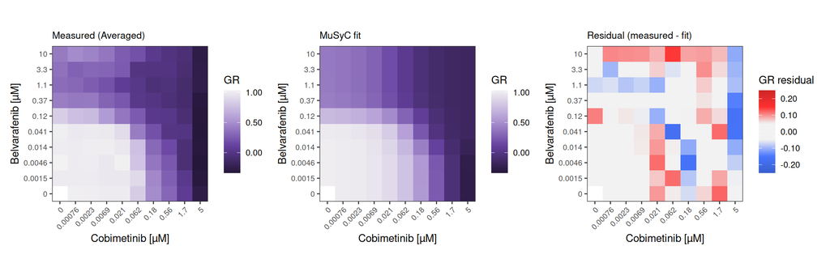

#### 8.3.2.16 MEL-JUSO (Vemurafenib x Cobimetinib)

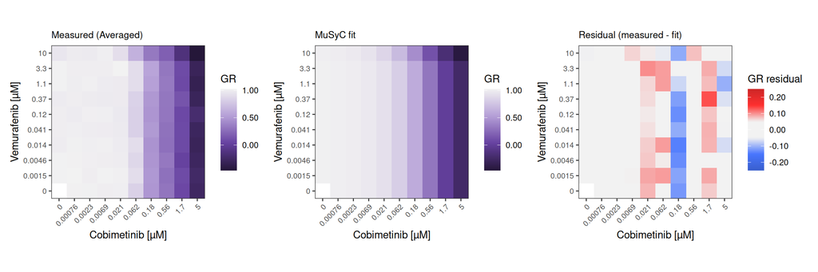

#### 8.3.2.17 SK-MEL-28 (Belvarafenib x Cobimetinib)

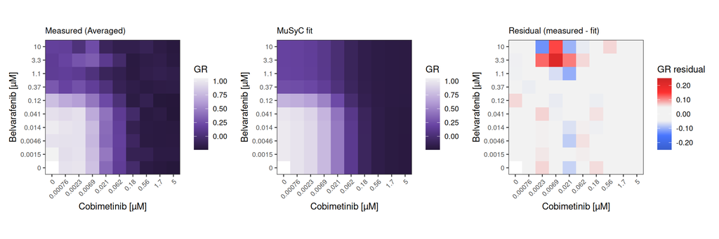

#### 8.3.2.18 SK-MEL-28 (Vemurafenib x Cobimetinib)

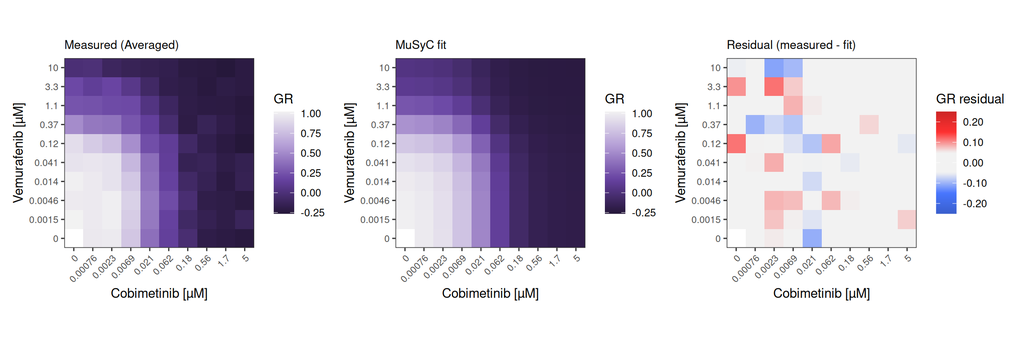

#### 8.3.2.19 WM-266-4 (Belvarafenib x Cobimetinib)

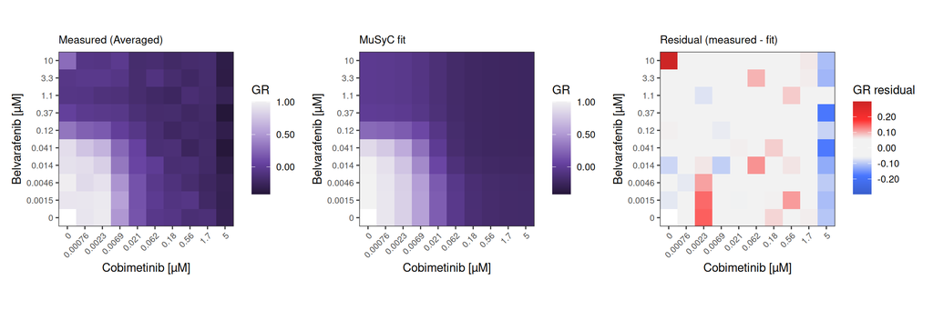

#### 8.3.2.20 WM-266-4 (Vemurafenib x Cobimetinib)

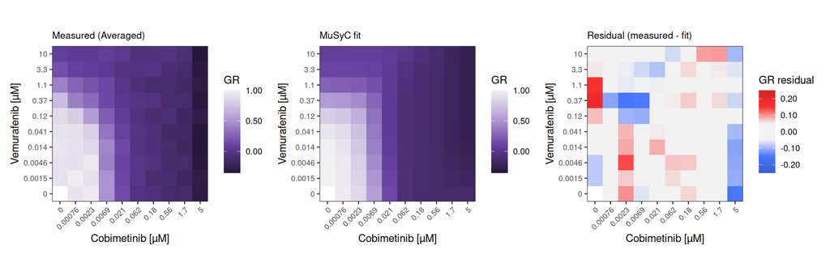

# 9 Provenance

`apply_fit()` records how each assay was produced in the SE metadata, so the numbers can be traced back to the exact model.

```r
summarize_fit_provenance(combo_se)
```

```
##             assay fit_source                                          fn
##            <char>     <char>                                      <char>
## 1:        Metrics        gDR      gDRcore::apply_combo_sa_fits (1.11.35)
## 2:         excess        gDR       gDRcore::apply_combo_excess (1.11.35)
## 3:   isobolograms        gDR gDRcore::apply_combo_isobolograms (1.11.35)
## 4: all_iso_points        gDR gDRcore::apply_combo_isobolograms (1.11.35)
## 5:         scores        gDR       gDRcore::apply_combo_scores (1.11.35)
## 6:   musyc_params      musyc             gDRcore::musyc_fit_fn (1.11.35)
## 7:  musyc_summary      musyc         gDRcore::musyc_summary_fn (1.11.35)
##                                                                                                                                                                                                                             fit_args
##                                                                                                                                                                                                                               <char>
## 1:                                                       series_identifiers = c("Concentration", "Concentration_2"), normalization_types = c("GR", "RV"), averaged_assay = "Averaged", metrics_assay = "Metrics", fit_source = "gDR"
## 2:                                                  series_identifiers = c("Concentration", "Concentration_2"), normalization_types = c("GR", "RV"), averaged_assay = "Averaged", metrics_assay = "Metrics", excess_assay = "excess"
## 3: series_identifiers = c("Concentration", "Concentration_2"), normalization_types = c("GR", "RV"), averaged_assay = "Averaged", metrics_assay = "Metrics", isobolograms_assay = "isobolograms", iso_points_assay = "all_iso_points"
## 4: series_identifiers = c("Concentration", "Concentration_2"), normalization_types = c("GR", "RV"), averaged_assay = "Averaged", metrics_assay = "Metrics", isobolograms_assay = "isobolograms", iso_points_assay = "all_iso_points"
## 5:                            scores_assay = "scores", averaged_assay = "Averaged", metrics_assay = "Metrics", excess_assay = "excess", normalization_types = c("GR", "RV"), fit_source = "gDR", isobolograms_assay = "isobolograms"
## 6:
## 7:
##                                                             model
##                                                            <char>
## 1: single-agent Hill fits along each axis of the combination grid
## 2:      HSA and Bliss excess over smoothed single-agent responses
## 3:                       Loewe isobolograms and combination index
## 4:                       Loewe isobolograms and combination index
## 5:           Bliss, HSA and CI scores per drug pair and cell line
## 6:              MuSyC (multi-dimensional synergy of combinations)
## 7:                                          MuSyC synergy summary
```

# 10 Save the results

```r
write_xlsx(
  list(musyc_params = musyc_params, musyc_summary = musyc_summary,
       musyc_summary_by_norm = musyc_summary_by_norm),
  file.path(wd, "tables", "musyc_params.xlsx")
)
```

# 11 Conclusion

A new model was fitted to the processed combination data by passing one function to `apply_fit()`. The same pattern applies to any model that maps the responses of one cell to a set of numbers: write the fit function, call `apply_fit()`, and the results travel with the data, provenance included.

### We Value Your Feedback!

Thank you for using gDR! We are always looking to improve, and your feedback is incredibly valuable to us.

[Share feedback or request features on GitHub](https://github.com/gdrplatform/gDRworkshops/issues)

# 12 gDR session info

```r
gdr_elapsed <- (proc.time() - gdr_start_time)[["elapsed"]]
message(sprintf("Report generated in %.1f seconds", gdr_elapsed))
gdr_sdt <- get_gDR_session_info()
generate_datatable(gdr_sdt)
```

|  | Package | Version |
| --- | --- | --- |
| 1 | gDR | 1.11.29 |
| 2 | gDRcore | 1.11.35 |
| 3 | gDRimport | 1.11.17 |
| 4 | gDRplots | 0.99.17 |
| 5 | gDRtestData | 1.11.14 |
| 6 | gDRutils | 1.11.27 |

```r
cat(sprintf("**Report generation time: %.1f seconds**", gdr_elapsed))
```

```
## **Report generation time: 82.0 seconds**
```